# RMarkdown Demo

Intro to RMarkdown

Sean Conway  
5/28/2022

```r
2+2
```

```
[1] 4
```

The primary purpose of RMarkdown documents is the sharing of a data analysis with others.

For this class, we will use the `distill` package to create RMarkdown posts. `distill` is a great `R` package for creating professional looking blog posts from RMarkdown files. Make sure you have `distill` installed on your computer.

## R operations

```r
library(ggplot2)
library(dplyr)
```

### Subheadings

This is a subheading. To create headings with further down levels, simply add more `#` symbols.

#### Sub-subheadings

You can write plain text in the white space.  
But, make sure to always double space when you want to go to a new line.  
This applies to headings as well.

This is my line.  
This is another line.

## R Coding in RMarkdown

You can include as many R code chunks as you want in an RMarkdown document. Any objects you create in one code chunk will be available in your environment.

### Running code chunks

```r
x <- c(1,2,3,4)
x + 2
```

```
[1] 3 4 5 6
```

```r
x/3
```

```
[1] 0.3333333 0.6666667 1.0000000 1.3333333
```

and `x` is still available in our environment:

```r
x
```

```
[1] 1 2 3 4
```

```r
1
```

```
[1] 1
```

```r
2
```

```
[1] 2
```

```r
2
```

```
[1] 2
```

```r
3
```

```
[1] 3
```

```r
2
```

```
[1] 2
```

RMarkdown is great for showing your work to others. Regular `R` scripts (files that end in .R) are great for computationally intensive work, but for simpler analyses that are necessary to present to others, RMarkdown is hard to beat.

### Directories in R/RMarkdown

- the working directory of an RMarkdown file is the location of the file on your computer

[figure not shown]

- here, the file path for this script on my computer is ‘/Users/seanconway/Teaching/DACSS_601_Su22/scripts/Rmd_Demo.Rmd’
- Say there was a data file one folder “back” on my computer. To read in the data, I would run:

```r
library(readr)
my_data <- read_delim("../data.txt")
```

### Example visualization in RMarkdown

Here we use the pre-built in dataset `mtcars` to visualize the relationship between weight and miles-per-gallon in cars.

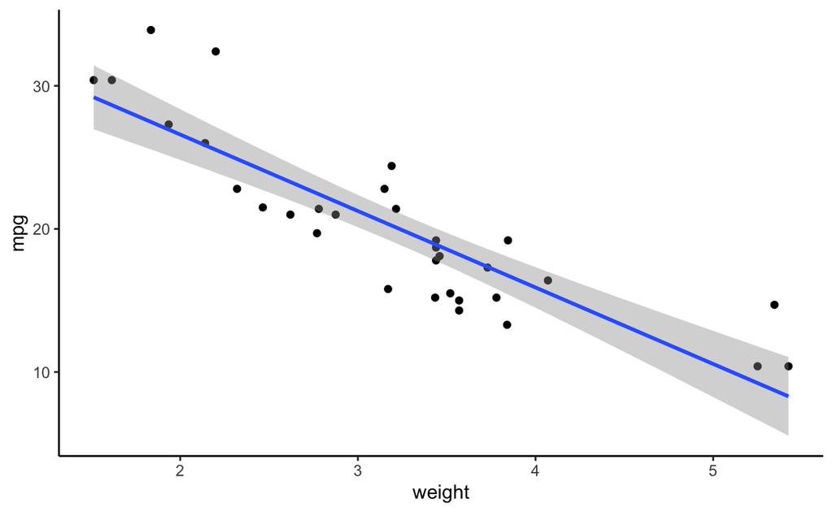

```r
mtcars <- as_tibble(mtcars)
ggplot(mtcars, aes(wt,mpg))+
  geom_point()+
  geom_smooth(method="lm")+
  labs(x="weight","mpg")+
  theme_classic()
```

## Code Chunk Options

There are various settings for code chunks. Sometimes you may want to include a computation in your script, but you don’t need readers to see it. For example, say I want to simulate some data, but I don’t need to bog down readers with my simulation code. I can use the `echo=F` setting to make sure that the simulation code is hidden.

Below, I simulate some data from a linear regression model (the details of this are irrelevant). Setting `echo=F` will hide this from the reader.

Now, I’ll show the reader a visualization of this simulated data.

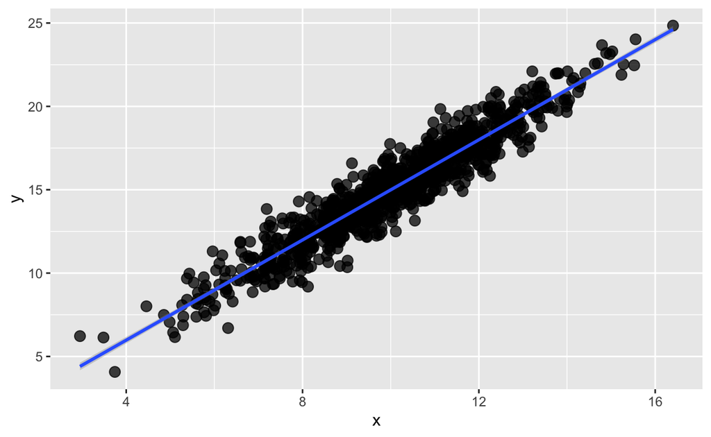

```r
ggplot(dat, aes(x,y))+
  geom_point(size=3,alpha=.75)+
  geom_smooth(method="lm")
```

Sometimes running an `R` command will output a message that we don’t need the reader to see. This often happens when loading `R` packages. To avoid this, we can use the command `message=F` to make sure it doesn’t print the message. I’ll demonstrate this when I load the `BayesFactor` package for Bayesian statistical analysis (details of this package are irrelevant for this course).

```r
# load bayes factor package
library(BayesFactor)
```

Sometimes we want to show the reader a particular `R` command without actually running it. For example, I might want to show the reader that they should install the package `dplyr` to do a set of analysis. However, I **already** have `dplyr` installed in my `R`, so there’s no need for me to run the command. Here, I’ll use the `eval=F` setting to print the command in proper `R` syntax highlighting, but without actually running the command.

```r
install.packages("dplyr")
```

## Other notes about RMarkdown

- Still include comments in code to aid others in understanding your code (use the `#` symbol to make a comment)
- Chunking output in console
- Preview settings
- Knitting
- Directories and RMarkdown
- Code chunks for other languages?!?
- Code chunk options
  - `echo`
  - `eval`
  - `warning`
  - `message`
- Output format
  - `distill::distill_article` (to be used for this class)
    - when using `distill`, always include a blank line between texts and code chunks
  - html
  - pdf
  - Microsoft Word document
- RMarkdown Cheatsheet by RStudio
  - https://www.rstudio.com/wp-content/uploads/2015/02/rmarkdown-cheatsheet.pdf
- The RMarkdown Cookbook by Xie, Dervieux, & Riederer (2021)
  - https://bookdown.org/yihui/rmarkdown-cookbook/